# Initial exploration of SCEPTRE (full score statistic) resampling distributions

Tim

2022-12-24

# Intro

I briefly explore the empirical permutation distribution of the full score statistic that we use within SCEPTRE. The data frame of resampling distributions is as follows.

```r
library(evmix)
library(tidyverse)
sceptre2_results_dir <- paste0(.get_config_path("LOCAL_SCEPTRE2_DATA_DIR"), "results/")
# load empirical distributions
resampling_dists <- readRDS(paste0(sceptre2_results_dir, "resampling_distributions/sceptre_resampling_dists.rds"))
resampling_dists[1:5, 1:6]
```

```
##   response_id grna_group eff_ss                 dataset        z_1        z_2
## 1       ABCF3       PYGB     14 frangieh/ifn_gamma/gene -0.8599081  0.4955902
## 2    ABRAXAS1       FMN1     20 frangieh/ifn_gamma/gene  0.7154867  0.5882412
## 3  AC010618.3    TMEM173     12 frangieh/ifn_gamma/gene -0.4637156 -0.5671471
## 4      VPS33B    TMEM173      9 frangieh/ifn_gamma/gene -0.1293690  0.2334101
## 5  AC025159.1      JMJD7     20 frangieh/ifn_gamma/gene -0.4503102 -0.6261187
```

There are 330 rows, each of which corresponds to a different gene-gRNA pair. The dataset and “effective sample size” (or `eff_ss’), defined as the number of treatment cells with nonzero expression, also are included as columns. The “Effective sample size” varies from 7 (our QC threshold) to 30.

```r
resampling_dists |>
  select(eff_ss, dataset) |>
  group_by(dataset, eff_ss) |>
  summarize(count = n()) |>
  print(n = 33)
```

```
## # A tibble: 33 × 3
## # Groups:   dataset [3]
##    dataset                                eff_ss count
##    <fct>                                   <int> <int>
##  1 frangieh/ifn_gamma/gene                     7    10
##  2 frangieh/ifn_gamma/gene                     8    10
##  3 frangieh/ifn_gamma/gene                     9    10
##  4 frangieh/ifn_gamma/gene                    10    10
##  5 frangieh/ifn_gamma/gene                    12    10
##  6 frangieh/ifn_gamma/gene                    14    10
##  7 frangieh/ifn_gamma/gene                    16    10
##  8 frangieh/ifn_gamma/gene                    18    10
##  9 frangieh/ifn_gamma/gene                    20    10
## 10 frangieh/ifn_gamma/gene                    25    10
## 11 frangieh/ifn_gamma/gene                    30    10
```

[output cut: 22 more lines]

Below, I write functions `analyze_pair` and `make_plot` that facilitate analyzing rows of the resampling distribution data frame. The funtion `analyze_pair` takes as input two arguments: (i) the row of the resampling distribution data frame to analyze, and (ii) the resampling distribution data frame itself. The function `make_plot` takes as input the output of `analyze_pair` and prints some helpful information about that pair.

```r
compute_one_sided_p_value <- function(z_null, z_star, right_tail = TRUE, cutoff = 0.99) {
  # investigate left tail or right tail
  z_null <- (if (right_tail) 1 else -1) * z_null
  u <- quantile(z_null, cutoff)[[1]]
  z_null_tail <- z_null[z_null > u]

  # fit GDP via MLE
  fit <- fgpd(x = z_null, u = u) # does the p-value estimate remain stable if we downsample z_null?

  # get the density of the fitted distribution
  x_grid <- seq(u, max(z_null_tail), length.out = 1000)
  y_dens <- dgpd(x = x_grid, u = u, sigmau = fit$mle[1], xi = fit$mle[2])
  fit_df <- data.frame(x = x_grid, y = y_dens)

  p <- data.frame(z = z_null_tail) |>
    ggplot(mapping = aes(x = z, y = after_stat(density))) +
    geom_histogram(bins = 30, fill = "grey", col = "black") +
    theme_bw() +
    geom_line(data = fit_df, mapping = aes(x = x, y = y), col = "blue") +
    geom_vline(xintercept = z_star, col = "red") +
    ggtitle(if(right_tail) "Right tail" else "Left tail")

  # compute the one-sided p-value
  emp_p <- mean(z_null > u) *  (1 - sceptre2:::compute_empirical_p_value(z_star, z_null_tail, side = "left"))
  p_p <- mean(z_null > u) * (1 - pgpd(q = z_star, u = u, sigmau = fit$mle[1], xi = fit$mle[2]))
  return(list(p = p, emp_p = emp_p, p_p = p_p))
}


analyze_pair <- function(i, resampling_dists) {
  info <- resampling_dists[i, 1:4]
  z_null <- (resampling_dists[i, 5:ncol(resampling_dists)] |> as.numeric())
  z_star <- quantile(abs(z_null), 0.99998)[[1]]

  p <- data.frame(z = z_null) |>
    ggplot(mapping = aes(x = z, y = after_stat(density))) +
    geom_histogram(bins = 30, fill = "grey", col = "black") +
    theme_bw() +
    geom_vline(xintercept = z_star, col = "red") +
    geom_vline(xintercept = -z_star, col = "red") +
    ggtitle("Whole distribution")

  left_tail <- compute_one_sided_p_value(z_null = z_null,
                                         z_star = z_star,
                                         right_tail = FALSE,
                                         cutoff = 0.99)

  right_tail <- compute_one_sided_p_value(z_null = z_null,
                                          z_star = z_star,
                                          right_tail = TRUE,
                                          cutoff = 0.99)

  return(list(left_tail = left_tail, right_tail = right_tail,
              whole_dist = p, info = info))
}

make_plot <- function(res) {
  plot(cowplot::plot_grid(res$whole_dist, res$left_tail$p, res$right_tail$p, ncol = 3))
  m <- matrix(c(res$left_tail$emp_p,
           res$left_tail$p_p,
           res$right_tail$emp_p,
           res$right_tail$p_p), nrow = 2)
  colnames(m) <- c("P(z_null < -|z|)", "P(z_null > |z|)")
  rownames(m) <- c("Empirical", "Parametric")
  print(m)
  cat("\n")
  print(res$info)
}
```

For example, below I call `analyze_pair` — followed by `make_plot` — on the third row of the resampling distribution data frame.

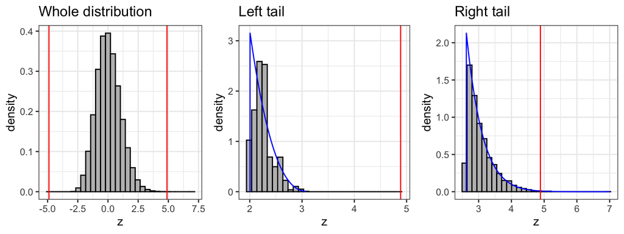

```
##            P(z_null < -|z|) P(z_null > |z|)
## Empirical                 0    1.999600e-05
## Parametric                0    3.082469e-05
##
##   response_id grna_group eff_ss                 dataset
## 3  AC010618.3    TMEM173     12 frangieh/ifn_gamma/gene
```

```r
analyze_pair(3, resampling_dists) |> make_plot()
```

I describe the outputs here. First, we have a plot of the empirical permutation distribution alongside the tails of this distribution. The leftmost plot shows the whole permutation distribution; the middle plot shows the left tail of the distribution, and the rightmost plot shows the right tail of the distribution. (I multiplied the test statistics $z_1, ..., z_{500,000}$ by negative 1 to create the left-tail plot.) I also plot the generalized Pareto distribution (GPD) fitted to both left and right tails of the distribution, which is superimposed on top of the histograms. Finally, the vertical red line represents a large value that we might obtain for the observed test statistic, $z_{obs}$. (Both $|z_{obs}|$ and $-|z_{obs}|$ are plotted). In particular, $z_{obs}$ is selected so that the empirical right-tailed p-value computed using $|z_{obs}|$ (or, equivalently, the left-tailed p-value computed using $-|z_{obs}|$) is equal to about 2e-5; our p-values need to be accurate out to about this level.

Next, the 2-by-2 table shows one-sided p-values. The columns correspond to $\mathbb{P}(z_{null} < -|z_{obs}|)$ and $\mathbb{P}(z_{null} > |z_{obs}|)$, respectively, and the rows correspond to whether the above probabilities are computed using the empirical distribution (top) or the parametric generalized Pareto distribution (bottom).

Finally, I print some information about this pair: the response ID, the gRNA group, the effective sample size, and the dataset from which the pair came.

# Some examples

I use the functions `analyze_pair` and `make_plot` to investigate several pairs. First, I plot a pair whose effective sample size is 7.

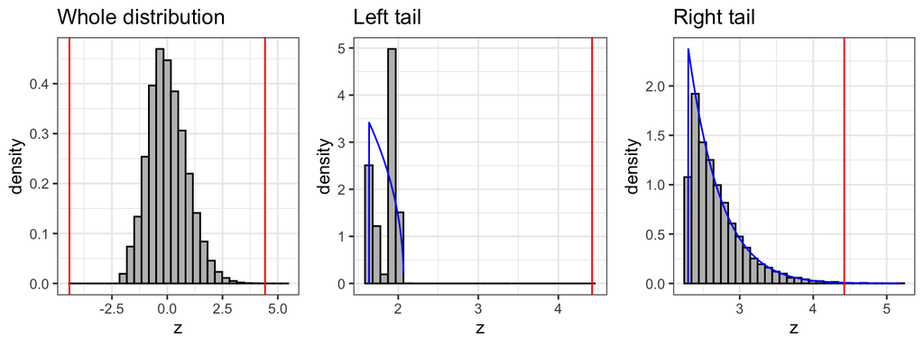

```
##            P(z_null < -|z|) P(z_null > |z|)
## Empirical                 0    1.999600e-05
## Parametric                0    1.910019e-05
##
##    response_id grna_group eff_ss                 dataset
## 26     CCDC189    TXNDC17      7 frangieh/ifn_gamma/gene
```

```r
analyze_pair(26, resampling_dists) |> make_plot()
```

The whole distribution clearly is asymmetric. The left tail is short and bumpy, providing a poor fit to the GPD. The right tail, meanwhile, is long and well-behaved, providing a very good fit to the GPD.

Now, I plot a pair whose effective sample size is 8.

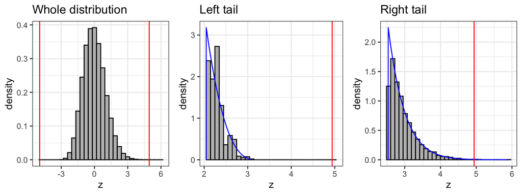

```
##            P(z_null < -|z|) P(z_null > |z|)
## Empirical                 0    1.999600e-05
## Parametric                0    1.698906e-05
##
##    response_id grna_group eff_ss                 dataset
## 57       NADK2    PIK3IP1      8 frangieh/ifn_gamma/gene
```

```r
analyze_pair(57, resampling_dists) |> make_plot()
```

The story is similar to above: the left tail is short and bumpy, providing a poor fit to the GPD, while the right tail is long and nice, providing a good fit.

Next, I investigate a pair whose effective sample size is 12.

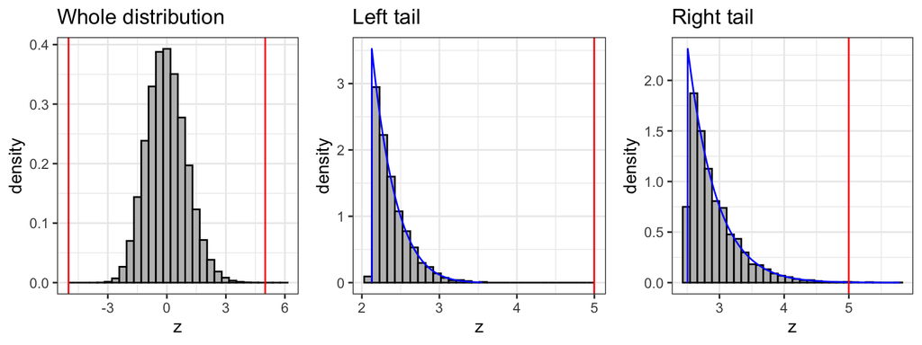

```
##            P(z_null < -|z|) P(z_null > |z|)
## Empirical                 0    1.999600e-05
## Parametric                0    1.229838e-05
##
##    response_id grna_group eff_ss                 dataset
## 72         MTR      NOLC1     12 frangieh/ifn_gamma/gene
```

```r
analyze_pair(72, resampling_dists) |> make_plot()
```